# Investigating a Dataset

## Questions related to Titanic Dataset:

1. What factors made people more likely to survive?
2. Does the surviving rate depend upon the age or sex of the people?
3. Does Higher class people survive more when compared to lower class people?

```python
import numpy as np
import matplotlib.pyplot as plt
import pandas as pd
from pandas import DataFrame
import seaborn as sns
```

The data from the csv file is read and the number of rows and columns are identified.

```python
tdata = pd.read_csv("titanic-data.csv")
tdata.shape
```

```
(891, 12)
```

This table displays the column details of the table.

```python
tdata.head()
```

|  | PassengerId | Survived | Pclass | Name | Sex | Age | SibSp | Parch | Ticket | Fare | Cabin | Embarked |
| --- | --- | --- | --- | --- | --- | --- | --- | --- | --- | --- | --- | --- |
| 0 | 1 | 0 | 3 | Braund, Mr. Owen Harris | male | 22.0 | 1 | 0 | A/5 21171 | 7.2500 | NaN | S |
| 1 | 2 | 1 | 1 | Cumings, Mrs. John Bradley (Florence Briggs Th... | female | 38.0 | 1 | 0 | PC 17599 | 71.2833 | C85 | C |
| 2 | 3 | 1 | 3 | Heikkinen, Miss. Laina | female | 26.0 | 0 | 0 | STON/O2. 3101282 | 7.9250 | NaN | S |
| 3 | 4 | 1 | 1 | Futrelle, Mrs. Jacques Heath (Lily May Peel) | female | 35.0 | 1 | 0 | 113803 | 53.1000 | C123 | S |
| 4 | 5 | 0 | 3 | Allen, Mr. William Henry | male | 35.0 | 0 | 0 | 373450 | 8.0500 | NaN | S |

```python
tdata.head().groupby('Survived')['Sex'].describe()
```

| Survived | count | unique | top | freq |
| --- | --- | --- | --- | --- |
| 0 | 2 | 1 | male | 2 |
| 1 | 3 | 1 | female | 3 |

**Null Hypothesis (H0):** From the dataset, we take 5 samples and then we estimate the Survival.  
When the Survival rate is seen, all the female survived and no male survived.

The extra data which is not required can be cleared so that analysis can be made easier.

# Data Wrangling Phase

Out of 891 dataset, the Ages of 177 people are missing. This data should be filtered before Analyzing. So, The missing data is removed from the original data and the values for 714 dataset is analyzed. This is done by filtering the data by using **dropna()** function. The dataset with values are taken and the ones without the values are ignored. This phase is called Data Wrangling Phase.

```python
filtered_data = tdata.loc[:,['Survived','Pclass','Sex','Age','SibSp']]
updated_data = filtered_data.dropna()
updated_data.shape
```

```
(714, 5)
```

```python
updated_data.corr()
```

|  | Survived | Pclass | Age | SibSp |
| --- | --- | --- | --- | --- |
| Survived | 1.000000 | -0.359653 | -0.077221 | -0.017358 |
| Pclass | -0.359653 | 1.000000 | -0.369226 | 0.067247 |
| Age | -0.077221 | -0.369226 | 1.000000 | -0.308247 |
| SibSp | -0.017358 | 0.067247 | -0.308247 | 1.000000 |

## Comparing the dataset based on gender:

A function to implement a Bar graph:

```python
def bar_graph(x_data, y_data, x_desc, y_desc, g_data, title):
    sns.barplot(x = x_data, y = y_data, data = g_data)
    plt.title(title)
    plt.xlabel(x_desc)
    plt.ylabel(y_desc)
    plt.show()
```

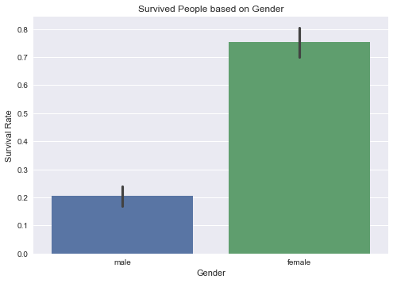

```python
bar_graph('Sex', 'Survived', 'Gender', 'Survival Rate', updated_data, 'Survived People based on Gender')
```

```python
tdata.groupby('Survived')['Sex'].describe()
```

| Survived | count | unique | top | freq |
| --- | --- | --- | --- | --- |
| 0 | 549 | 2 | male | 468 |
| 1 | 342 | 2 | female | 233 |

From the above bar chart, we can analyse that the number of women survived is very much higher than the number of men survived.

Now, we can group the data according to the **Age** of people. We can analyse whether the people who are younger survived or the older people survived.

A function to implement a Histogram:

```python
survived_people = updated_data[updated_data['Survived'] == 1]
dead_people = updated_data[updated_data['Survived'] == 0]
```

```python
def plot_histogram(ages, x, y):
    plt.xlabel(x)
    plt.ylabel(y)
    plt.hist(ages, color = 'indigo')
    plt.show()
```

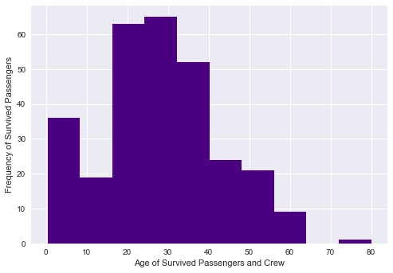

```python
plot_histogram(survived_people['Age'], 'Age of Survived Passengers and Crew', 'Frequency of Survived Passengers')
```

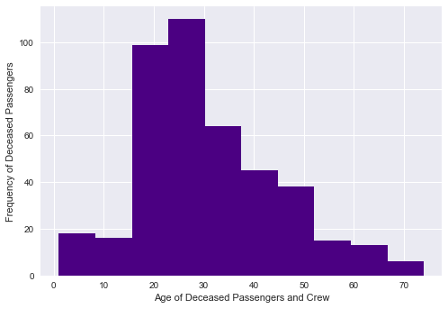

```python
plot_histogram(dead_people['Age'], 'Age of Deceased Passengers and Crew', 'Frequency of Deceased Passengers')
```

```python
tdata.groupby('Survived')['Age'].describe()
```

| Survived | count | mean | std | min | 25% | 50% | 75% | max |
| --- | --- | --- | --- | --- | --- | --- | --- | --- |
| 0 | 424.0 | 30.626179 | 14.172110 | 1.00 | 21.0 | 28.0 | 39.0 | 74.0 |
| 1 | 290.0 | 28.343690 | 14.950952 | 0.42 | 19.0 | 28.0 | 36.0 | 80.0 |

From the above two Histograms, we can see that the people between the ages 15 and 45 are more in number in the ship. Both has approximately equal number of average death and survival rates. The average number of people aged **28** were able to survive and the Average number of people aged **30** were not able to survive. The people between the ages 60 and 80 were not able to survive when compared to the Younger people.

```python
updated_data.corr()
```

|  | Survived | Pclass | Age | SibSp |
| --- | --- | --- | --- | --- |
| Survived | 1.000000 | -0.359653 | -0.077221 | -0.017358 |
| Pclass | -0.359653 | 1.000000 | -0.369226 | 0.067247 |
| Age | -0.077221 | -0.369226 | 1.000000 | -0.308247 |
| SibSp | -0.017358 | 0.067247 | -0.308247 | 1.000000 |

```python
updated_data.groupby('Sex')['Survived'].mean()
```

```
Sex
female    0.754789
male      0.205298
Name: Survived, dtype: float64
```

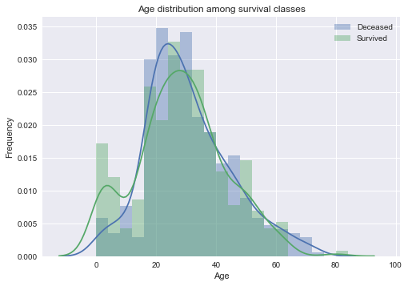

```python
age_bins = np.arange(0, 100, 4)
sns.distplot(tdata.loc[(tdata['Survived']==0) & (~tdata['Age'].isnull()),'Age'], bins=age_bins)
sns.distplot(tdata.loc[(tdata['Survived']==1) & (~tdata['Age'].isnull()),'Age'], bins=age_bins)
plt.title('Age distribution among survival classes')
plt.ylabel('Frequency')
plt.legend(['Deceased', 'Survived']);
plt.show()
```

Now Comparing the dataset of Pclass:

```python
tdata.groupby('Pclass')['Survived'].mean()
```

```
Pclass
1    0.629630
2    0.472826
3    0.242363
Name: Survived, dtype: float64
```

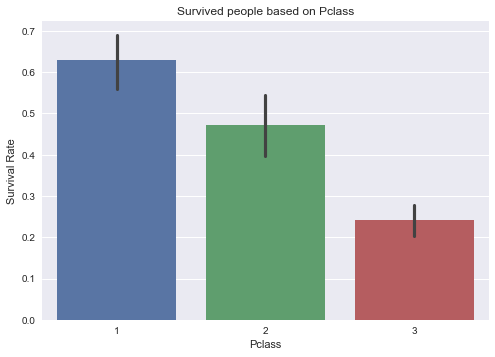

```python
bar_graph('Pclass', 'Survived', 'Pclass', 'Survival Rate', tdata, 'Survived people based on Pclass')
```

From the above mean values of each Pclass, we see that the higher class people survived more than the lower class people.

Now Checking the Null values in the dataset:

```python
tdata.isnull().sum()
```

```
PassengerId      0
Survived         0
Pclass           0
Name             0
Sex              0
Age            177
SibSp            0
Parch            0
Ticket           0
Fare             0
Cabin          687
Embarked         2
dtype: int64
```

From the Above data, we see that there are 177 Null values in Age and 687 Null values in Cabin.

### Some Predictions that could increase Survivability:

There are some data which could have some impact on the Survival rate. The people who spent more for the ticket, they would have got more facilities when compared to people who spent less. The cabin to which passengers belonged can also place its impact on Survival rate since the passengers whose cabin was far from boats could take more time to reach the boats when compared to the near cabins. If the incident occured in the day time, the survival rate would have increased or the incident could have been avoided. If the hull of ship was strong enough to sustain the colloidal, then the ship could have avoided the wreak.

## Conclusion:

```python
from scipy import stats as st
st.ttest_ind(survived_people['Age'], dead_people['Age'])
```

```
Ttest_indResult(statistic=-2.0666869462538102, pvalue=0.039124654013482488)
```

The disadvantage of this dataset is that there are several missing values in the table. The missing values affect the Analysis of the Data. Since the data is missing, the computations done above cannot be said accurate.

## References:

Seaborn plotting: https://seaborn.pydata.org/examples/index.html Numpy and Scipy: https://docs.scipy.org/doc/ Pandas Visualizations: https://pandas.pydata.org/pandas-docs/stable/visualization.html Udacity Data Analyst Course: https://classroom.udacity.com/nanodegrees/nd009-in-basic/parts/412b0bc9-0fc2-4e86-9cdb-4215583ce3a7 Clearing Doubts: https://stackoverflow.com/ Seaborn.pydata.org: (Link by mentor): http://seaborn.pydata.org/generated/seaborn.kdeplot.html

###### By: Himanshu Jain P